# Quick Start

Updated on : Mon Sep 26 23:49:39 2022

```r
library(EnWAS)
library(splines)
library(ggplot2)
```

## Load data

```r
data("nhanes")
data("exposure_vars")
```

## Base Model

We need to check the base model and ensure it runs correctly before performing EnWAS. The knots and boundary knots set are essential. The model may not perform as good as expected or raise errors if the knots are not set correctly.

```r
lm_str <- 'BPXDI1 ~ RIDAGEYR*RIAGENDR + BMXBMI'
lm_base <- lm(as.formula(lm_str), nhanes)

ns_str <-
  'BPXDI1 ~ ns(RIDAGEYR, knots = seq(30, 80, by = 10), Boundary.knots=c(20,90)
) * RIAGENDR + ns(BMXBMI,knots = c(seq(15, 45, by = 5),seq(45,75,by=10)), Boundary.knots=c(10,85))'
ns_base <- lm(as.formula(ns_str), nhanes)
```

## Residual Plots

We can check the residual trends against variables. For example, we can plot the residuals of the models against age. We can see the residuals of the linear model have a parabola-like trend, and the residuals of the natural spline model do not have a clear pattern.

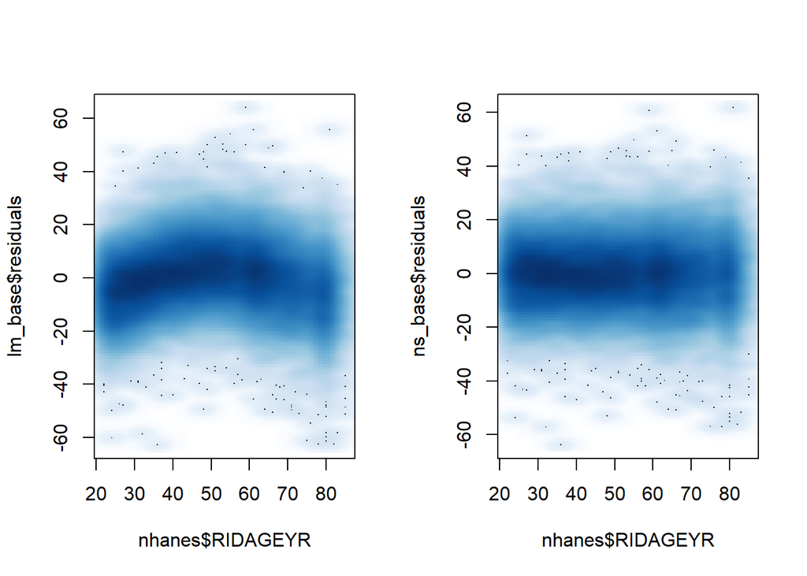

```r
par(mfrow = c(1, 2))
smoothScatter(nhanes$RIDAGEYR,lm_base$residuals)
smoothScatter(nhanes$RIDAGEYR,ns_base$residuals)
```

Further, we can binned the residual plot and compare the trends.The values on x-axis (age in this example) are binned, and each bin contains about 600 data points; further the mean of residuals are plotted with error bar ([$-1.96 \sqrt{\sigma_r},1.96\sqrt{\sigma_r}]$), where $\sqrt{\sigma_r}$ is the standard deviation of residuals in the bins. The binned residual can stretch the data point out so that it shows clear patterns of the residuals in each bin.

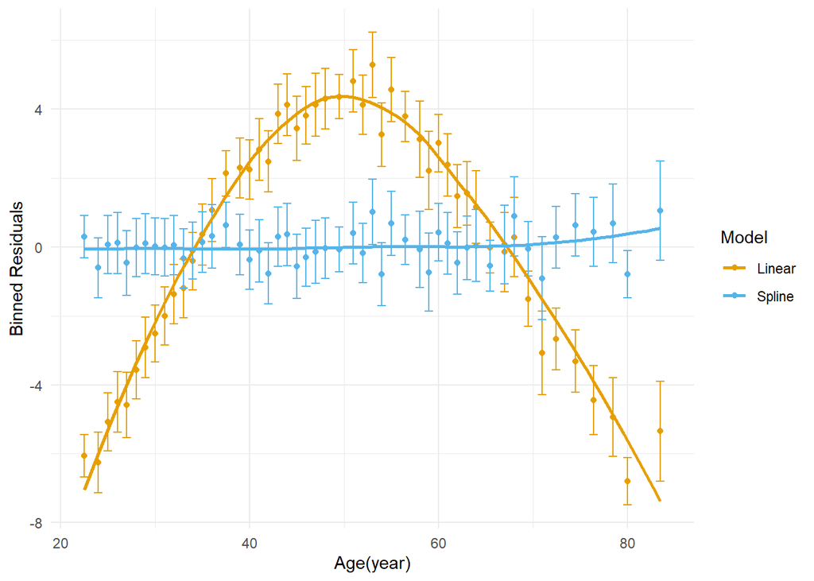

```r
df_age_res <- list("Linear"=make_bins(x=nhanes$RIDAGEYR,y=lm_base$residual,nbin=600),
                "Spline"=make_bins(x=nhanes$RIDAGEYR,y=ns_base$residuals,nbin=600)
                )
plot_bins2(df_age_res,xlab="Age(year)", ylab="Binned Residuals",is_facet=FALSE)
```

## AIC/BIC

We can also check the models, with AIC and BIC to select the models.

```r
library(knitr)
kable(broom::glance(lm_base)[c("df", "logLik", "AIC", "BIC")])
```

| df | logLik | AIC | BIC |
| --- | --- | --- | --- |
| 4 | -120822.1 | 241656.3 | 241706.3 |

```r
kable(broom::glance(ns_base)[c("df", "logLik", "AIC", "BIC")])
```

| df | logLik | AIC | BIC |
| --- | --- | --- | --- |
| 27 | -119221.1 | 238500.2 | 238742.1 |

## ANOVA LRT (Likelihood Ratio Test)

```r
print_anova(anova(lm_base,ns_base,test="LRT"))
```

Analysis of Variance Table  
Model 1: BPXDI1 ~ RIDAGEYR * RIAGENDR + BMXBMI  
Model 2: BPXDI1 ~ ns(RIDAGEYR, knots = seq(30, 80, by = 10), Boundary.knots = c(20,  
90)) * RIAGENDR + ns(BMXBMI, knots = c(seq(15, 45, by = 5),  
seq(45, 75, by = 10)), Boundary.knots = c(10, 85))

| Res.Df | RSS | Df | Sum of Sq | Pr(>Chi) |
| --- | --- | --- | --- | --- |
| 31067 | 4338763 |  |  |  |
| 31044 | 3913900 | 23 | 424862.997 | < 0.001 |

## Run EnWAS

### Forest Plot

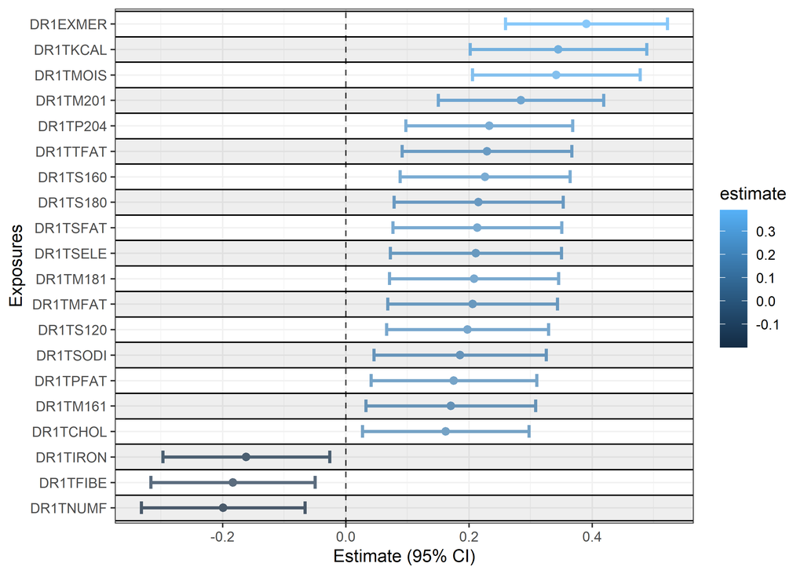

```r
lm_enwas <- enwas(lm_str, exposure_vars, nhanes)
ns_enwas <- enwas(ns_str, exposure_vars, nhanes)

forest_plot(lm_enwas$enwas_res)
```

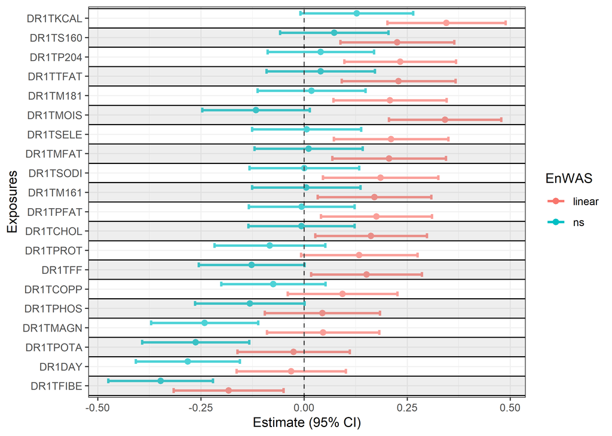

```r
forest_plot_mult(
  list(
    linear = lm_enwas$enwas_res,
    ns = ns_enwas$enwas_res
  )
)
```

### P-Value or FDR

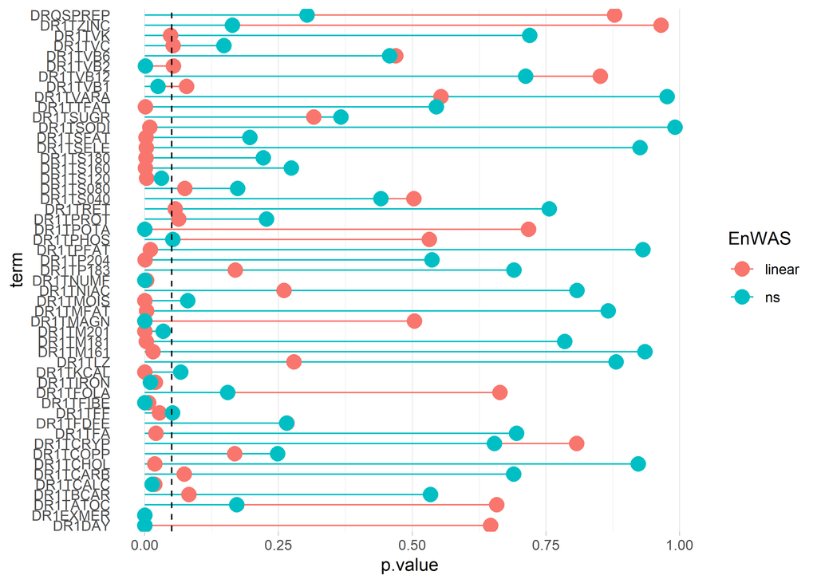

```r
plot_p(list(linear = lm_enwas$enwas_res,  ns = ns_enwas$enwas_res))
```

### Inverse Normal Transformation

In addition, the EnWAS model can use inverse normal transformation on the wide association variables, which would be helpful to improve the models’ performance when the distributions are skewed.

$$\operatorname{INT}\left(W_{i}\right)=\Phi^{-1}\left\{\frac{\operatorname{rank}\left(W_{i}\right)-c}{n+1-2
c}\right\}, c \in[0,1 / 2]$$
where c=3/8 is recommended.

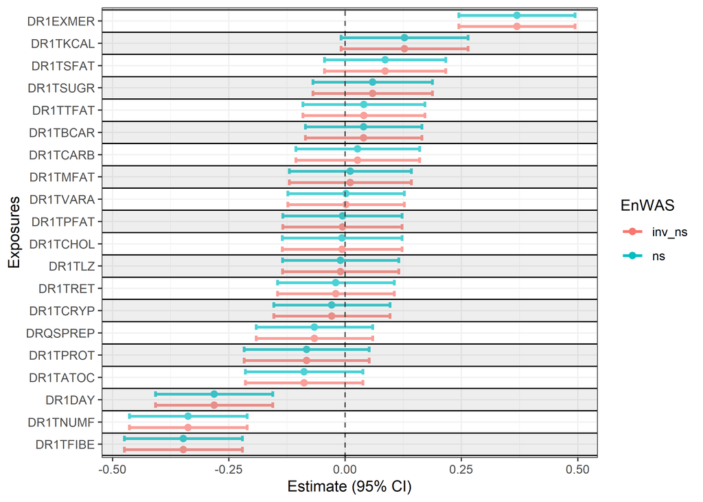

```r
ns_inv_enwas <- enwas(ns_str, exposure_vars, nhanes)
forest_plot_mult(
  list(
    inv_ns = ns_inv_enwas$enwas_res,
    ns = ns_enwas$enwas_res
  )
)
```